# ProyectoUnidad3

2024-05-29

# Importación de datos

Este dataset fue obtenido desde Kaggle (https://www.kaggle.com/datasets/rohit265/credit-card-eligibility-data-determining-factors) y luego fue re-subido a github para poder ser obtenido desde cualquier parte y dispositivo.

```r
library(readr)
dataset <- read_csv("https://raw.githubusercontent.com/ShinichiKD/analisisExploratorio/main/dataset.csv",
    col_types = cols(Gender = col_factor(levels = c("1",
        "0")), Own_car = col_factor(levels = c("1",
        "0")), Own_property = col_factor(levels = c("1",
        "0")), Work_phone = col_factor(levels = c("1",
        "0")), Phone = col_factor(levels = c("1",
        "0")), Email = col_factor(levels = c("1",
        "0")), Unemployed = col_factor(levels = c("1",
        "0")), Num_children = col_integer(),
        Num_family = col_integer(), Account_length = col_integer(),
        Total_income = col_double(), Income_type = col_factor(levels = c("Working",
            "Commercial associate", "Pensioner",
            "State servant", "Student")),
        Education_type = col_factor(levels = c("Secondary / secondary special",
            "Higher education", "Incomplete higher",
            "Lower secondary", "Academic degree")),
        Family_status = col_factor(levels = c("Married",
            "Single / not married", "Civil marriage",
            "Separated", "Widow")), Housing_type = col_factor(levels = c("House / apartment",
            "With parents", "Municipal apartment",
            "Rented apartment", "Office apartment")),
        Occupation_type = col_character(),
        Target = col_factor(levels = c("1",
            "0"))))
dataset <- dataset %>% select(-ID)
dataset$Occupation_type <- as.factor(dataset$Occupation_type)
dataset$Housing_type <- as.factor(dataset$Housing_type)
summary(dataset)
```

```
##  Gender   Own_car  Own_property Work_phone Phone    Email    Unemployed
##  1:3386   1:3570   1:6520       1:2111     1:2793   1: 850   1:1696
##  0:6323   0:6139   0:3189       0:7598     0:6916   0:8859   0:8013
##
##
##
##
##
##   Num_children       Num_family     Account_length   Total_income
##  Min.   : 0.0000   Min.   : 1.000   Min.   : 0.00   Min.   :  27000
##  1st Qu.: 0.0000   1st Qu.: 2.000   1st Qu.:13.00   1st Qu.: 112500
##  Median : 0.0000   Median : 2.000   Median :26.00   Median : 157500
##  Mean   : 0.4228   Mean   : 2.183   Mean   :27.27   Mean   : 181228
##  3rd Qu.: 1.0000   3rd Qu.: 3.000   3rd Qu.:41.00   3rd Qu.: 225000
##  Max.   :19.0000   Max.   :20.000   Max.   :60.00   Max.   :1575000
##
##       Age        Years_employed                  Income_type
##  Min.   :20.50   Min.   : 0.0000   Working             :4960
##  1st Qu.:34.06   1st Qu.: 0.9282   Commercial associate:2312
##  Median :42.74   Median : 3.7619   Pensioner           :1712
##  Mean   :43.78   Mean   : 5.6647   State servant       : 722
##  3rd Qu.:53.57   3rd Qu.: 8.2000   Student             :   3
##  Max.   :68.86   Max.   :43.0207
##
##                        Education_type              Family_status
##  Secondary / secondary special:6761   Married             :6530
##  Higher education             :2457   Single / not married:1359
##  Incomplete higher            : 371   Civil marriage      : 836
##  Lower secondary              : 114   Separated           : 574
##  Academic degree              :   6   Widow               : 410
##
##
##               Housing_type     Occupation_type Target
##  House / apartment  :8684   Other      :2994   1:1283
##  With parents       : 448   Laborers   :1724   0:8426
##  Municipal apartment: 323   Sales staff: 959
##  Rented apartment   : 144   Core staff : 877
##  Office apartment   :  76   Managers   : 782
##  NA's               :  34   Drivers    : 623
##                             (Other)    :1750
```

# Acerca del dataset

Este es el Conjunto de Datos de Elegibilidad para Tarjetas de Crédito. Involucra varios factores que determinan o influyen en la elegibilidad de una persona para una tarjeta de crédito. Desde variables demográficas como el género y el estado de empleo, hasta el número de hijos, el tamaño de la familia, el ingreso total, la educación, la ocupación y más allá, este conjunto de datos comprende la naturaleza multifacética de la evaluación para una tarjeta de crédito. Todos estos factores son necesarios para determinar la solvencia crediticia y la elegibilidad para una tarjeta de crédito.

### Variables presentes

- **ID**: Un identificador para cada individuo (cliente).
- **Gender**: El género del individuo.
- **Own_car**: Una característica binaria que indica si el individuo posee un automóvil.
- **Own_property**: Una característica binaria que indica si el individuo posee una propiedad.
- **Work_phone**: Una característica binaria que indica si el individuo tiene un teléfono de trabajo.
- **Phone**: Una característica binaria que indica si el individuo tiene un teléfono.
- **Email**: Una característica binaria que indica si el individuo ha proporcionado una dirección de correo electrónico.
- **Unemployed**: Una característica binaria que indica si el individuo está desempleado.
- **Num_children**: El número de hijos que tiene el individuo.
- **Num_family**: El número total de miembros de la familia.
- **Account_length**: La duración de la cuenta del individuo con un banco o institución financiera.
- **Total_income**: El ingreso total del individuo.
- **Age** : La edad del individuo.
- **Years_employed**: El número de años que el individuo ha estado empleado.
- **Income_type**: El tipo de ingreso (por ejemplo, empleado, autónomo, etc.).
- **Education_type**: El nivel educativo del individuo.
- **Family_status**: El estado familiar del individuo.
- **Housing_type**: El tipo de vivienda en la que vive el individuo.
- **Occupation_type**: El tipo de ocupación en la que está involucrado el individuo.
- **Target**: Indica si el individuo es elegible para una tarjeta de crédito o no (por ejemplo, Sí/No, 1/0). # Limpieza de Datos

### Datos faltantes

Primero observaremos los datos faltantes para cada columna.

```r
na_counts <- colSums(is.na(dataset))
print(na_counts)
```

```
##          Gender         Own_car    Own_property      Work_phone           Phone
##               0               0               0               0               0
##           Email      Unemployed    Num_children      Num_family  Account_length
##               0               0               0               0               0
##    Total_income             Age  Years_employed     Income_type  Education_type
##               0               0               0               0               0
##   Family_status    Housing_type Occupation_type          Target
##               0              34               0               0
```

```r
totalFaltantes<-sum(is.na(dataset))

numero_de_filas <- nrow(dataset)
porcentaje_faltantes <- (totalFaltantes / numero_de_filas) * 100
```

podemos observar que solamente Housing_type tiene datos faltantes, teniendo un 0.3501905 % de datos faltantes.

### Manejo de datos faltantes

Como existen un 0.3501905 % de datos faltantes, se eliminaran las filas.

```r
dataset <- na.omit(dataset)

na_counts <- colSums(is.na(dataset))
print(na_counts)
```

```
##          Gender         Own_car    Own_property      Work_phone           Phone
##               0               0               0               0               0
##           Email      Unemployed    Num_children      Num_family  Account_length
##               0               0               0               0               0
##    Total_income             Age  Years_employed     Income_type  Education_type
##               0               0               0               0               0
##   Family_status    Housing_type Occupation_type          Target
##               0               0               0               0
```

### Detectar datos atipicos

Se realizaran bloxplots de las variables númericas con el objetivo de detectar datos atipicos.

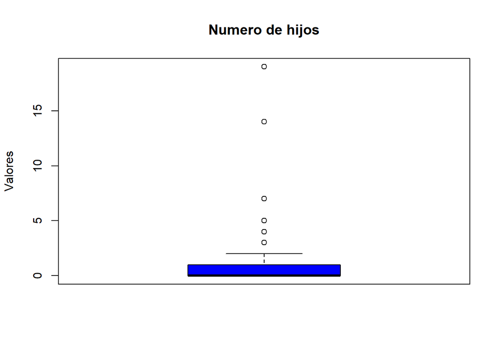

```r
boxplot(dataset$Num_children, main = "Numero de hijos", ylab = "Valores", col = "blue")
```

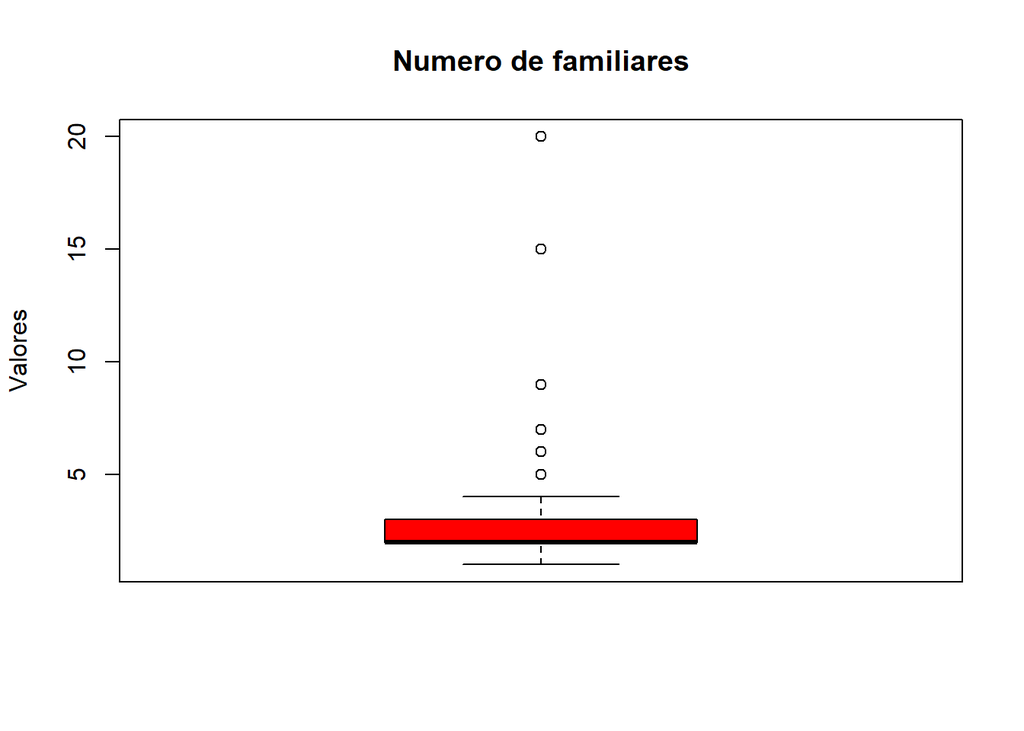

```r
boxplot(dataset$Num_family, main = "Numero de familiares", ylab = "Valores", col = "red")
```

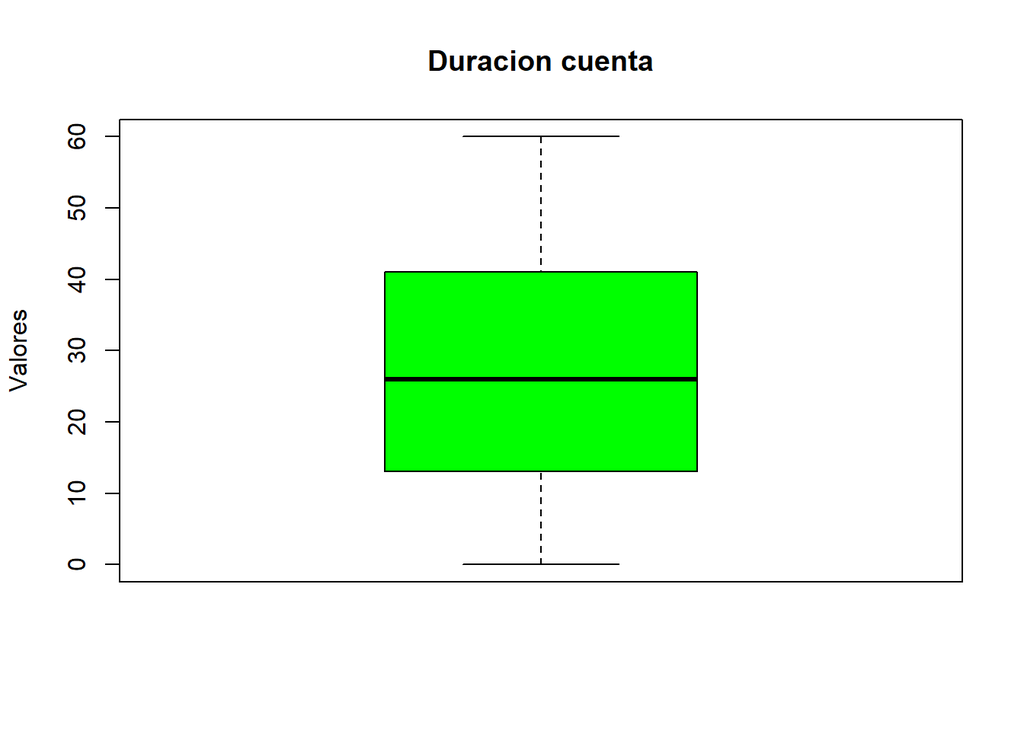

```r
boxplot(dataset$Account_length, main = "Duracion cuenta", ylab = "Valores", col = "green")
```

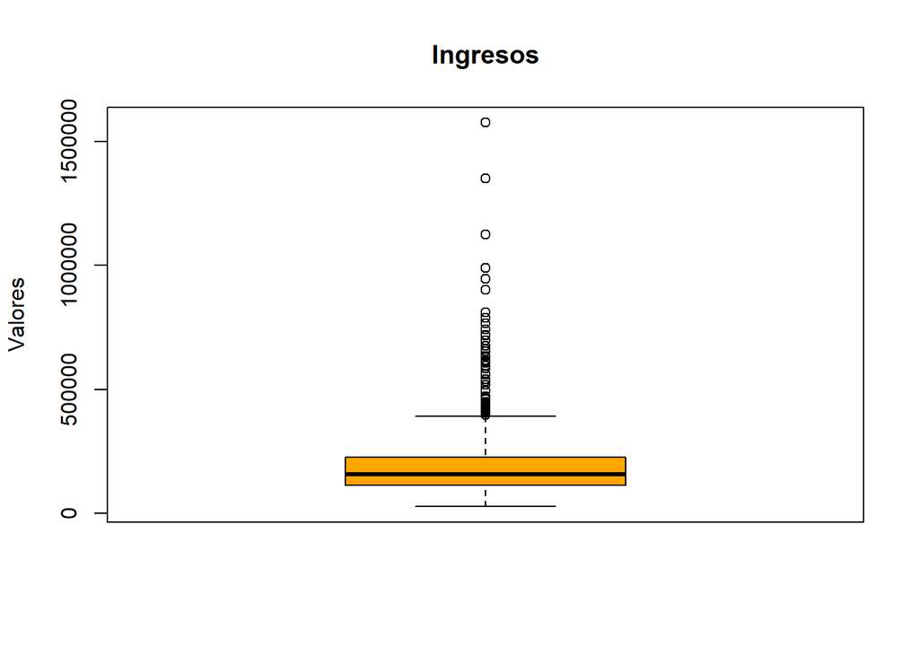

```r
boxplot(dataset$Total_income, main = "Ingresos", ylab = "Valores", col = "orange")
```

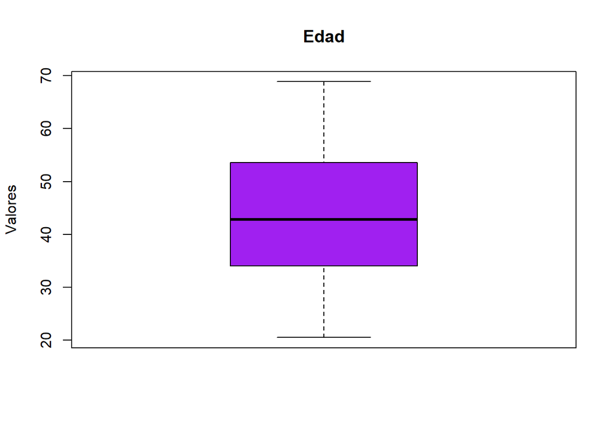

```r
boxplot(dataset$Age, main = "Edad", ylab = "Valores", col = "purple")
```

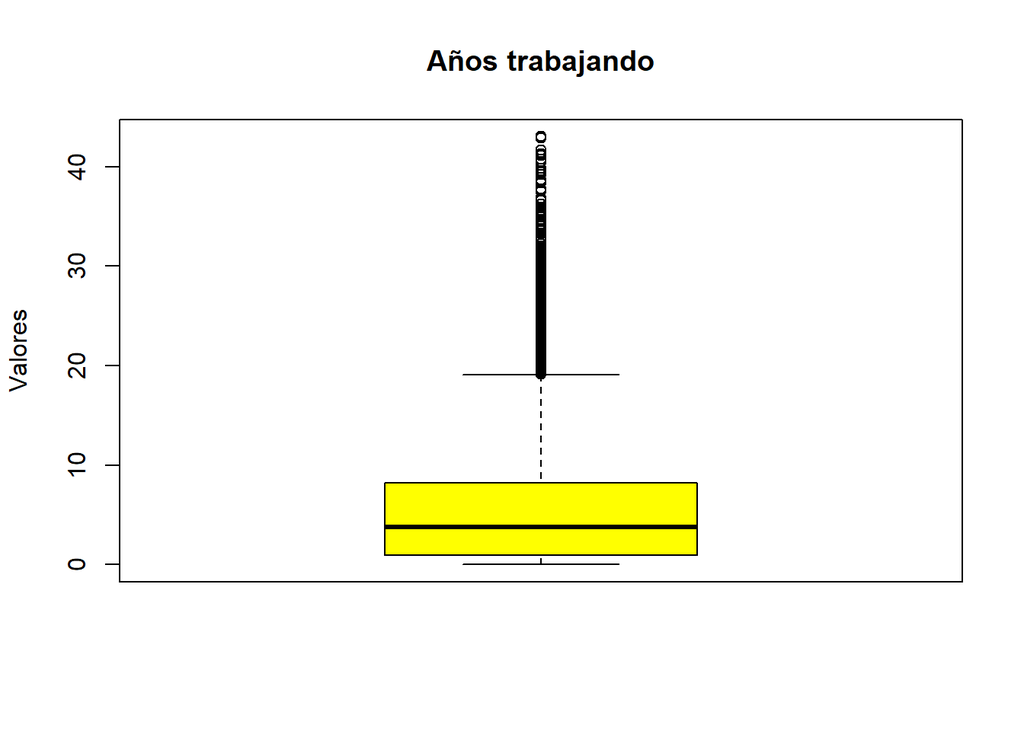

```r
boxplot(dataset$Years_employed, main = "Años trabajando", ylab = "Valores", col = "yellow")
```

### Manejar datos atipicos

Luego de visualizados, se eliminaran los valores atípicos utilizando el percentil 99 y el rango intercuartílico (IQR) para definir un límite superior, y luego filtra los datos para mantener solo aquellos valores que están por debajo de este límite superior.

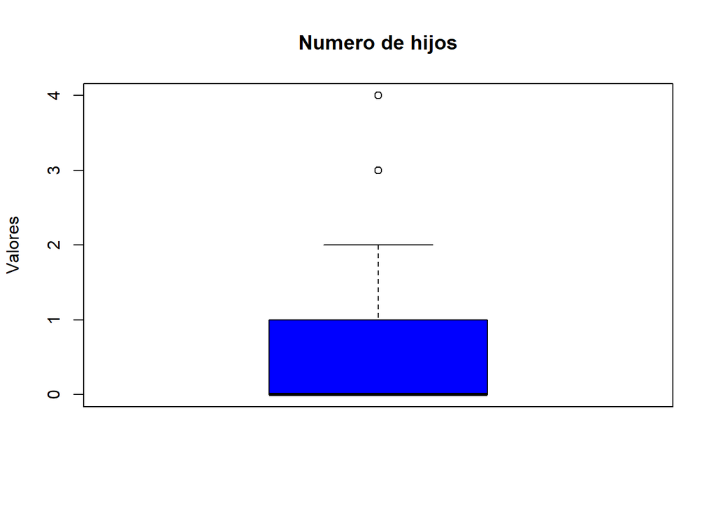

```r
remove_outliers <- function(data, column_name) {
  require(dplyr)

  bounds <- data %>%
    summarise(
      upper_bound = quantile(.data[[column_name]], 0.99) + 1.5 * IQR(.data[[column_name]])
    )

  filtered_data <- data %>%
    filter(.data[[column_name]] <= bounds$upper_bound)

  return(filtered_data)
}


# Calcular percentiles para la variable 'Total_income'
dataset <- remove_outliers(dataset,"Years_employed")
dataset <- remove_outliers(dataset,"Num_children")
dataset <- remove_outliers(dataset,"Num_family")
dataset <- remove_outliers(dataset,"Total_income")


boxplot(dataset$Num_children, main = "Numero de hijos", ylab = "Valores", col = "blue")
```

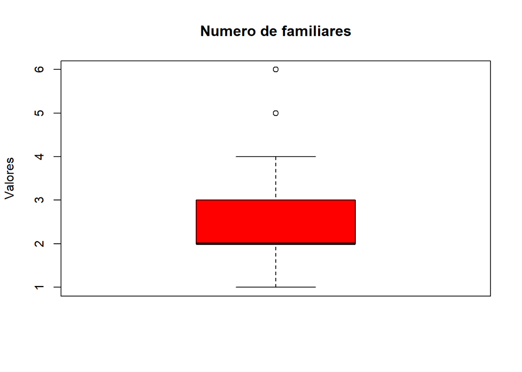

```r
boxplot(dataset$Num_family, main = "Numero de familiares", ylab = "Valores", col = "red")
```

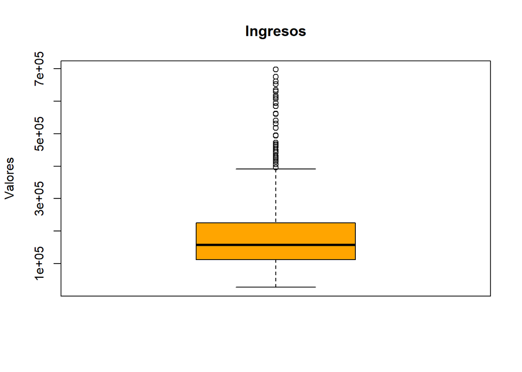

```r
boxplot(dataset$Total_income, main = "Ingresos", ylab = "Valores", col = "orange")
```

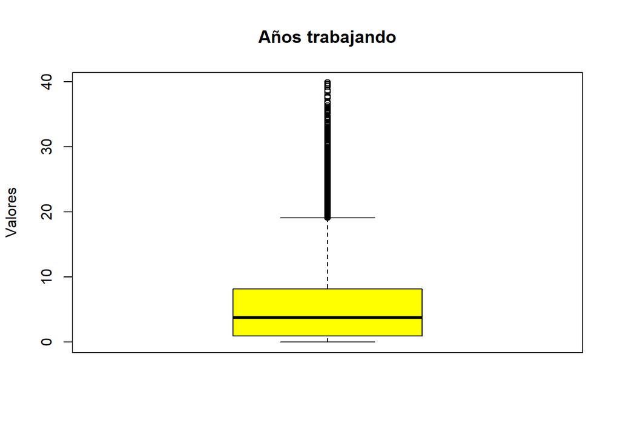

```r
boxplot(dataset$Years_employed, main = "Años trabajando", ylab = "Valores", col = "yellow")
```

## Realizar transformaciones - Codificación de Variables Categóricas: Se utilza One-Hot Encoding, para convertir las variables categóricas en variables numéricas. -Estandarización de Variables Continuas Se utilizara estandarización, para que tengan una media de 0 y una desviación estándar de 1.

```r
df_categorical <- dataset[, c("Gender", "Income_type", "Education_type", "Family_status", "Housing_type", "Occupation_type")]
df_categorical <- model.matrix(~ . - 1, data = df_categorical)


df_continuous <- dataset[, c("Total_income", "Age", "Years_employed", "Account_length")]
df_continuous <- scale(df_continuous)


df_binary <- dataset[, c("Own_car", "Own_property", "Work_phone", "Phone", "Email", "Unemployed")]


df_prepared <- cbind(df_binary, df_continuous, df_categorical)

head(df_prepared)
```

```
##   Own_car Own_property Work_phone Phone Email Unemployed Total_income
## 1       1            1          1     0     0          0    2.7645142
## 2       1            1          0     0     0          0   -0.7379519
## 3       0            1          0     1     1          0    1.0132811
## 4       0            1          0     0     0          1    1.1633868
## 5       1            1          1     1     1          0    1.0132811
## 6       1            1          0     0     0          0   -0.4877758
##          Age Years_employed Account_length Gender1 Gender0
## 1 -0.9389280      1.0859098     -0.7358656       1       0
## 2  1.2910589     -0.4032228      0.1052966       1       0
## 3  0.7343276      0.4344143     -1.3967788       0       1
## 4  1.5242079     -0.8987264     -0.4354505       0       1
## 5  0.2072697     -0.5627103     -1.3366957       1       0
## 6  0.4206363     -0.3770057     -0.6156996       1       0
##   Income_typeCommercial associate Income_typePensioner Income_typeState servant
```

[output cut: 111 more lines]

# Análisis descriptivo

Ahora se realizara un análisis descriptivo de las variables numericas y variablescategóricas.

```r
analyze_data <- function(df) {
  cat("Análisis para Variables Numéricas:\n")

  print(summary(df[sapply(df, is.numeric)]))
  print("Desviación estandar")
  print(sapply(df[sapply(df, is.numeric)], sd))


}

# Ejecutar la función de análisis
analyze_data(dataset)
```

```
## Análisis para Variables Numéricas:
##   Num_children      Num_family    Account_length   Total_income
##  Min.   :0.0000   Min.   :1.000   Min.   : 0.00   Min.   : 27000
##  1st Qu.:0.0000   1st Qu.:2.000   1st Qu.:13.00   1st Qu.:112500
##  Median :0.0000   Median :2.000   Median :26.00   Median :157500
##  Mean   :0.4161   Mean   :2.176   Mean   :27.25   Mean   :178869
##  3rd Qu.:1.0000   3rd Qu.:3.000   3rd Qu.:41.00   3rd Qu.:225000
##  Max.   :4.0000   Max.   :6.000   Max.   :60.00   Max.   :697500
##       Age        Years_employed
##  Min.   :20.50   Min.   : 0.0000
##  1st Qu.:34.06   1st Qu.: 0.9254
##  Median :42.76   Median : 3.7537
##  Mean   :43.78   Mean   : 5.6314
##  3rd Qu.:53.57   3rd Qu.: 8.1891
##  Max.   :68.86   Max.   :39.7982
## [1] "Desviación estandar"
##   Num_children     Num_family Account_length   Total_income            Age
##   7.200272e-01   8.971414e-01   1.664364e+01   8.993663e+04   1.162574e+01
## Years_employed
##   6.265921e+00
```

```
##
## Análisis de la columna: Gender
## [1] "Conteos"
##
##    1    0
## 3348 6281
##
##        1        0
## 34.76997 65.23003
```

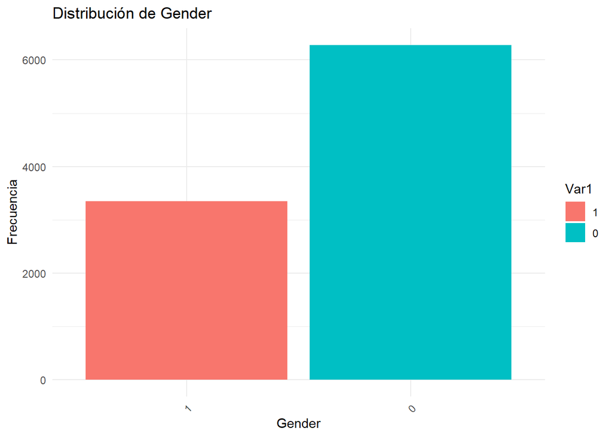

```
##
## Análisis de la columna: Own_car
## [1] "Conteos"
##
##    1    0
## 3525 6104
##
##        1        0
## 36.60816 63.39184
```

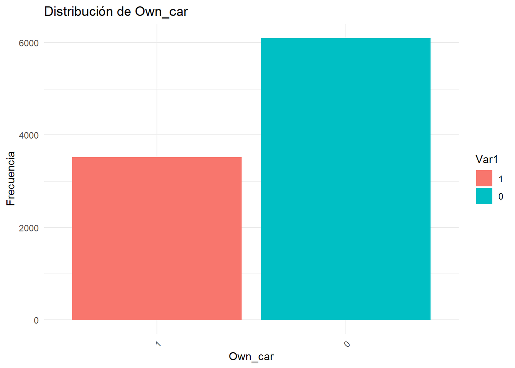

```
##
## Análisis de la columna: Own_property
## [1] "Conteos"
##
##    1    0
## 6463 3166
##
##        1        0
## 67.12016 32.87984
```

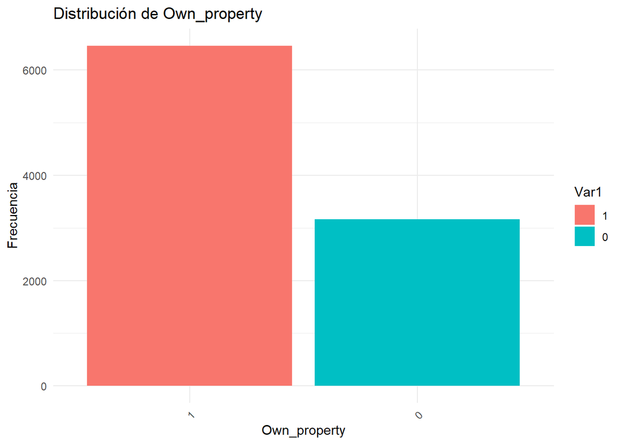

```
##
## Análisis de la columna: Work_phone
## [1] "Conteos"
##
##    1    0
## 2092 7537
##
##        1        0
## 21.72604 78.27396
```

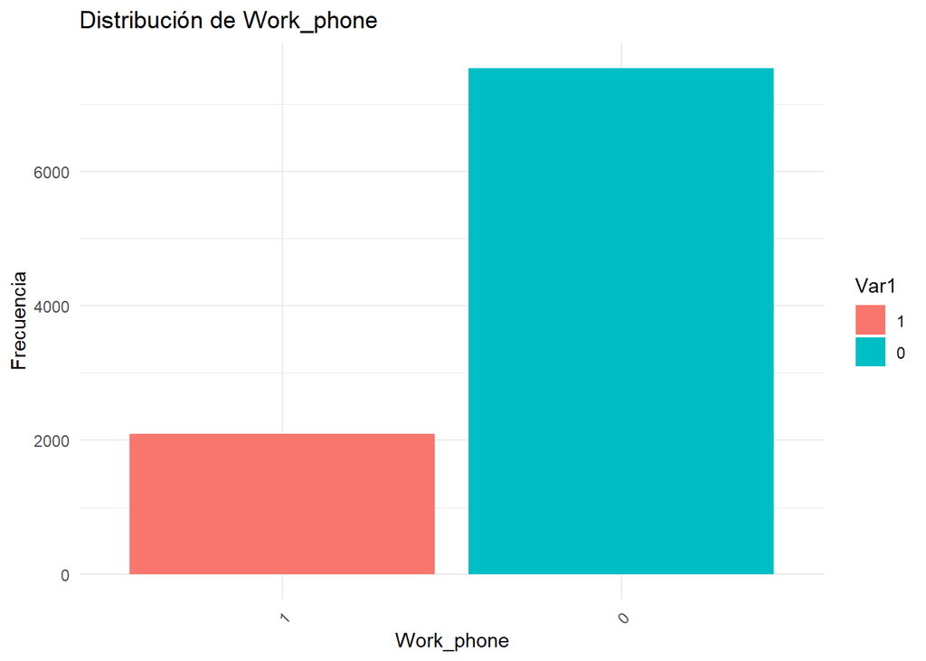

```
##
## Análisis de la columna: Phone
## [1] "Conteos"
##
##    1    0
## 2771 6858
##
##        1        0
## 28.77765 71.22235
```

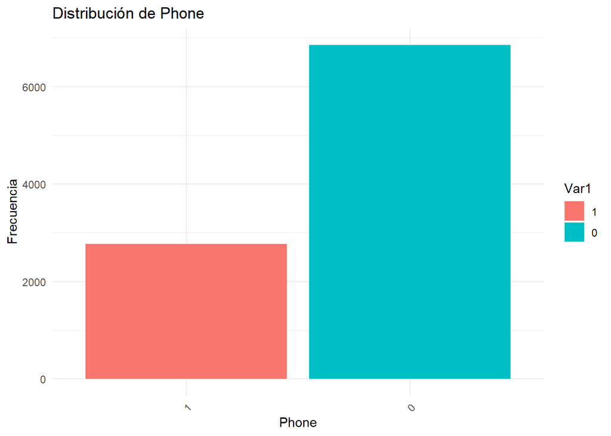

```
##
## Análisis de la columna: Email
## [1] "Conteos"
##
##    1    0
##  845 8784
##
##         1         0
##  8.775574 91.224426
```

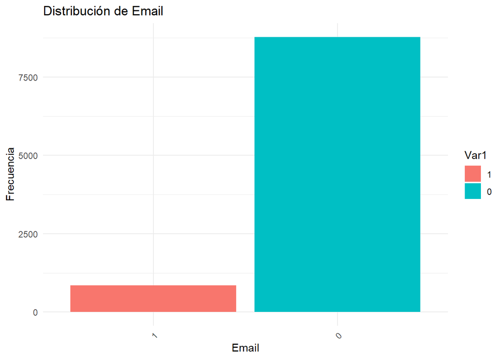

```
##
## Análisis de la columna: Unemployed
## [1] "Conteos"
##
##    1    0
## 1693 7936
##
##       1       0
## 17.5823 82.4177
```

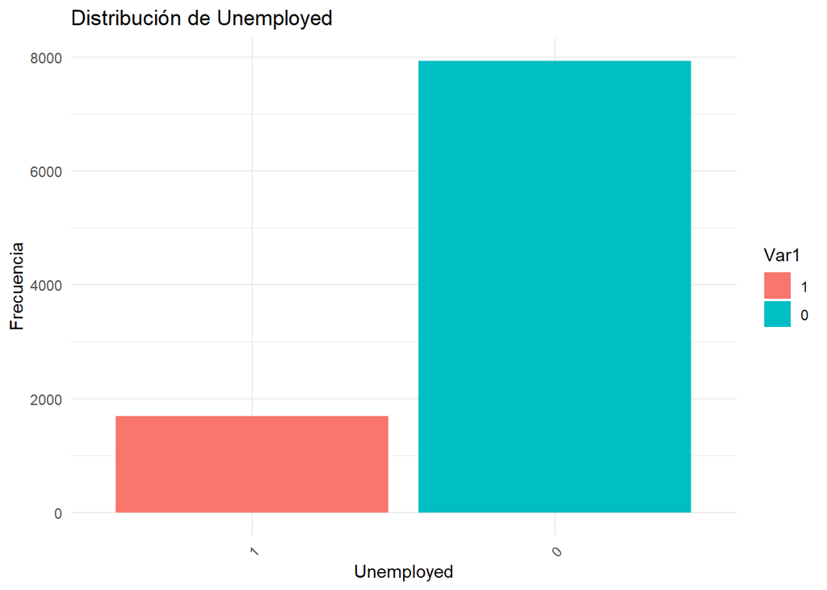

```
##
## Análisis de la columna: Income_type
## [1] "Conteos"
##
##              Working Commercial associate            Pensioner
##                 4918                 2289                 1709
##        State servant              Student
##                  710                    3
##
##              Working Commercial associate            Pensioner
##          51.07487797          23.77193893          17.74846817
##        State servant              Student
##           7.37355904           0.03115588
```

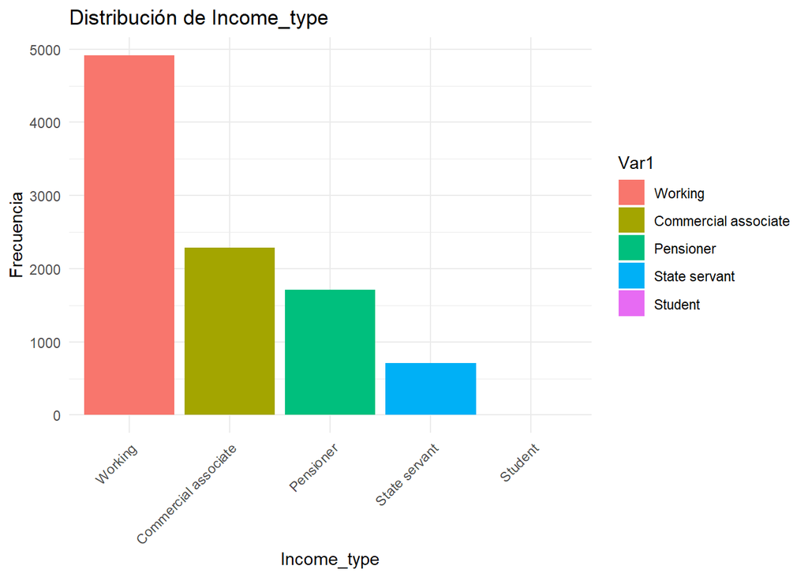

```
##
## Análisis de la columna: Education_type
## [1] "Conteos"
##
## Secondary / secondary special              Higher education
##                          6722                          2421
##             Incomplete higher               Lower secondary
##                           367                           113
##               Academic degree
##                             6
##
## Secondary / secondary special              Higher education
##                   69.80994911                   25.14279780
##             Incomplete higher               Lower secondary
##                    3.81140305                    1.17353827
##               Academic degree
##                    0.06231177
```

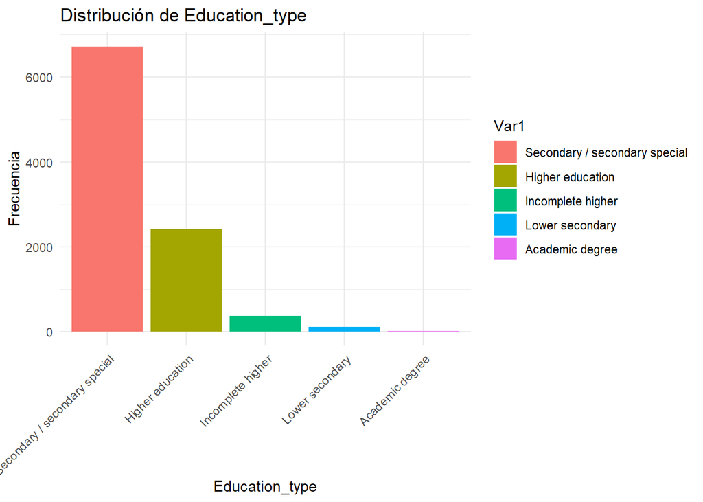

```
##
## Análisis de la columna: Family_status
## [1] "Conteos"
##
##              Married Single / not married       Civil marriage
##                 6478                 1346                  832
##            Separated                Widow
##                  566                  407
##
##              Married Single / not married       Civil marriage
##            67.275937            13.978606             8.640565
##            Separated                Widow
##             5.878077             4.226815
```

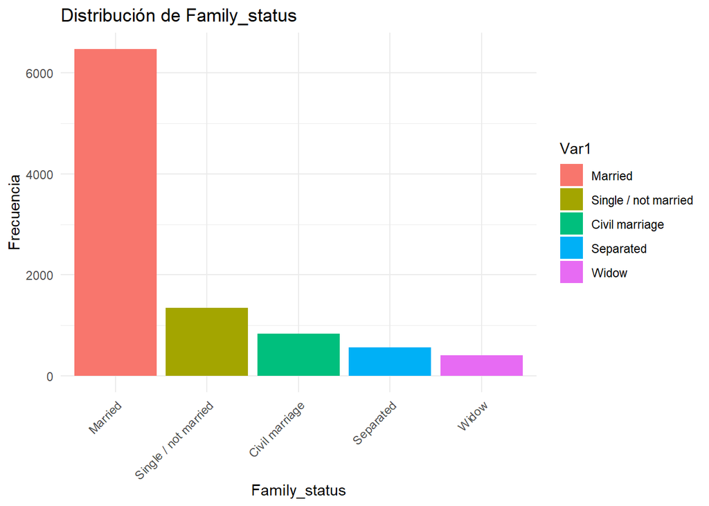

```
##
## Análisis de la columna: Housing_type
## [1] "Conteos"
##
##   House / apartment        With parents Municipal apartment    Rented apartment
##                8642                 447                 322                 143
##    Office apartment
##                  75
##
##   House / apartment        With parents Municipal apartment    Rented apartment
##          89.7497144           4.6422266           3.3440648           1.4850971
##    Office apartment
##           0.7788971
```

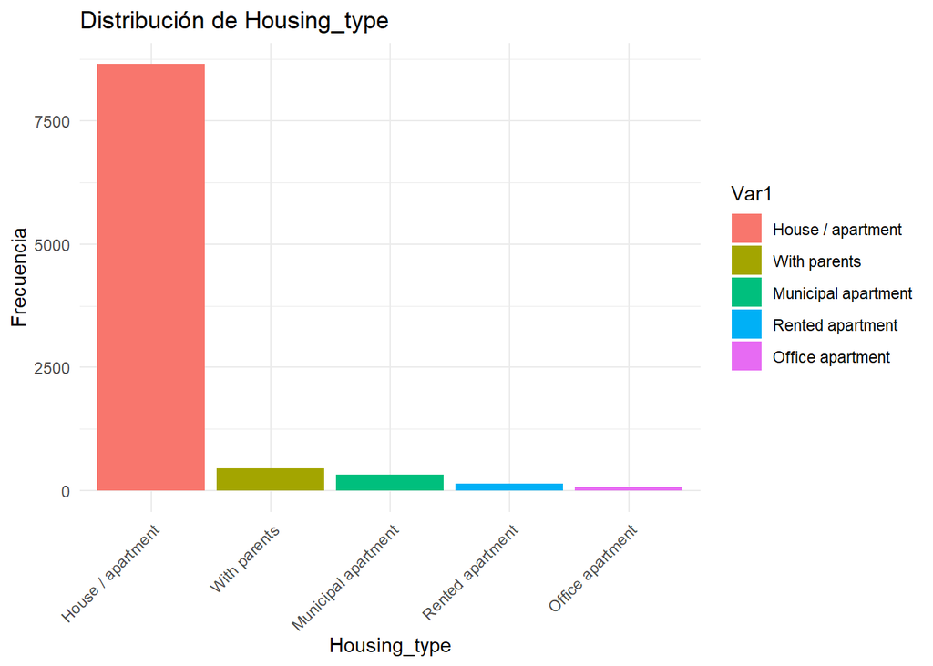

```
##
## Análisis de la columna: Occupation_type
## [1] "Conteos"
##
##           Accountants        Cleaning staff         Cooking staff
##                   298                   145                   192
##            Core staff               Drivers High skill tech staff
##                   870                   620                   352
##              HR staff              IT staff              Laborers
##                    22                    18                  1712
##    Low-skill Laborers              Managers        Medicine staff
##                    53                   759                   287
##                 Other Private service staff         Realty agents
##                  2979                    86                    16
##           Sales staff           Secretaries        Security staff
##                   955                    46                   180
##  Waiters/barmen staff
##                    39
##
##           Accountants        Cleaning staff         Cooking staff
##             3.0948177             1.5058677             1.9939765
##            Core staff               Drivers High skill tech staff
##             9.0352061             6.4388825             3.6556236
##              HR staff              IT staff              Laborers
##             0.2284765             0.1869353            17.7796241
##    Low-skill Laborers              Managers        Medicine staff
##             0.5504206             7.8824385             2.9805795
##                 Other Private service staff         Realty agents
##            30.9377921             0.8931353             0.1661647
##           Sales staff           Secretaries        Security staff
##             9.9179562             0.4777235             1.8693530
##  Waiters/barmen staff
##             0.4050265
```

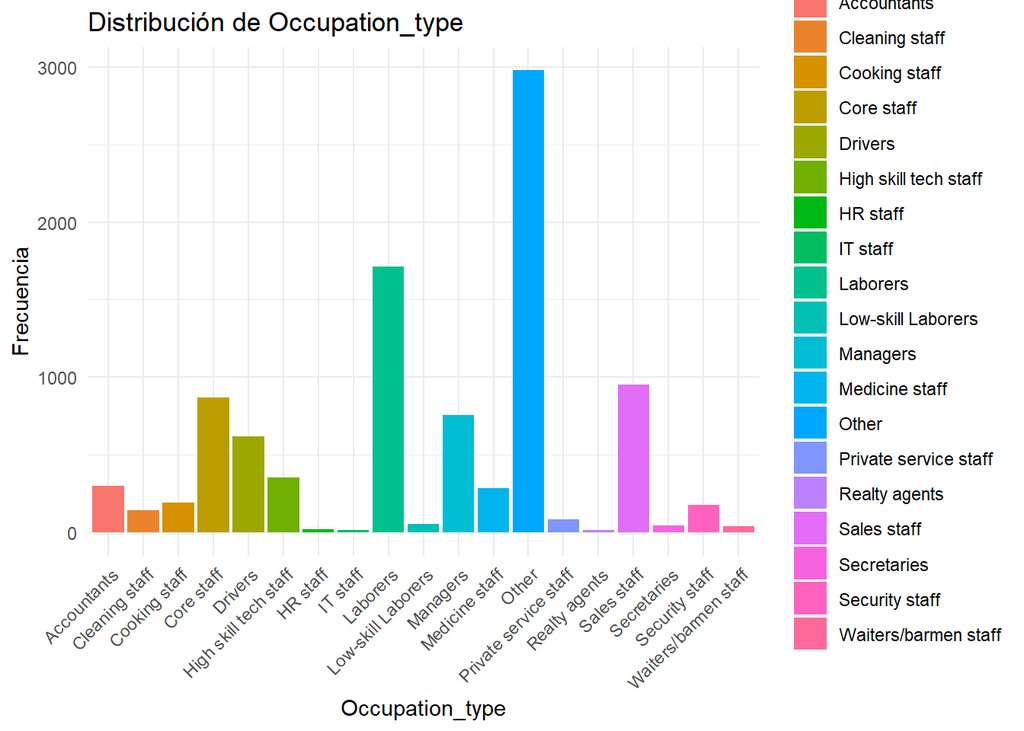

```
##
## Análisis de la columna: Target
## [1] "Conteos"
##
##    1    0
## 1269 8360
##
##        1        0
## 13.17894 86.82106
```

[1 more figures not shown]

```r
analyze_categorical <- function(df) {
  cat_columns <- sapply(df, is.factor)  # Encuentra columnas categóricas
  results <- lapply(names(df)[cat_columns], function(col) {
    cat(sprintf("\nAnálisis de la columna: %s\n", col))

    frecuencias <- table(df[[col]])
    proporciones <- prop.table(frecuencias) * 100
    print("Conteos")
    print(frecuencias)

    print(proporciones)
    df_frecuencias <- as.data.frame(frecuencias)
    p <- ggplot(df_frecuencias, aes_string(x = "Var1", y = "Freq", fill = "Var1")) +
         geom_bar(stat = "identity") +
         labs(title = sprintf("Distribución de %s", col), x = col, y = "Frecuencia") +
         theme_minimal()+
      theme(axis.text.x = element_text(angle = 45, hjust = 1))
    print(p)
  })
}
analyze_categorical(dataset)
```

# Formulación de Preguntas e Hipótesis

## Pregunta 1

- ¿Cuáles son los factores más relevantes que determinan la elegibilidad de una persona para obtener una tarjeta de crédito?
- Hipótesis: Los factores más influyentes en la determinación de la elegibilidad para una tarjeta de crédito son el ingreso total, los años de empleo y la posesión de propiedad.

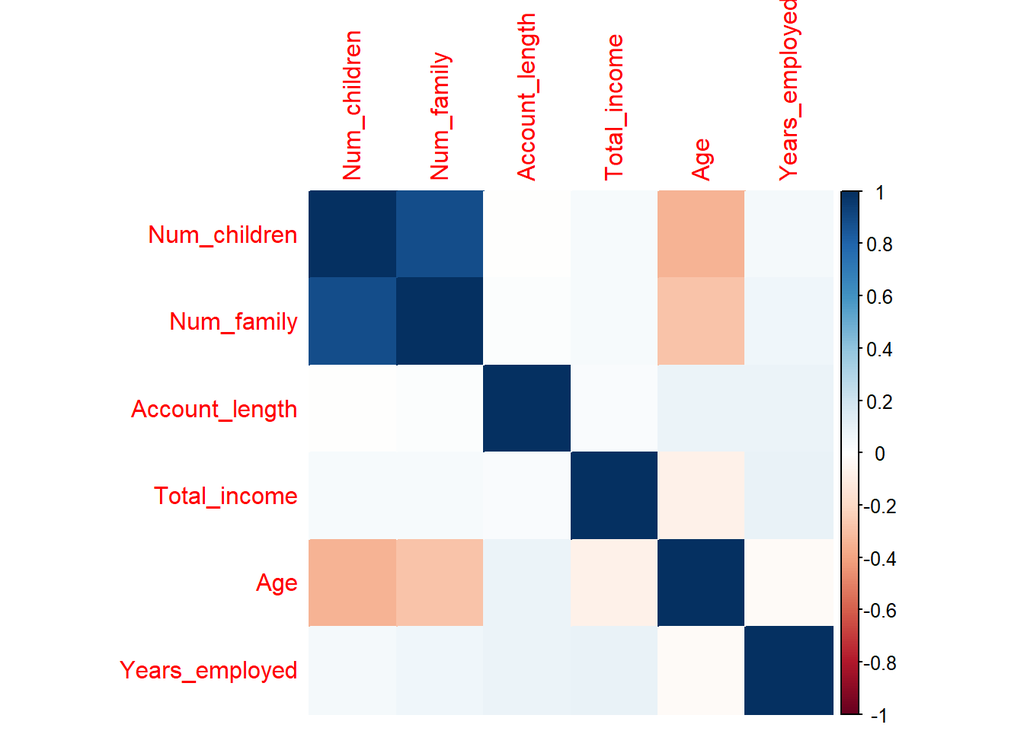

```r
numerics <- sapply(dataset, is.numeric)
data_corr <- dataset[, numerics]

# Calcular matriz de correlación
cor_matrix <- cor(data_corr, use = "complete.obs")

# Graficar el mapa de calor de correlaciones
corrplot(cor_matrix, method = "color")
```

### Pregunta 2

- ¿Es posible establecer perfiles de solicitantes basados en las características presentes en el dataset?
- Hipótesis: Los solicitantes se pueden clasificar en distintos perfiles basados en sus características

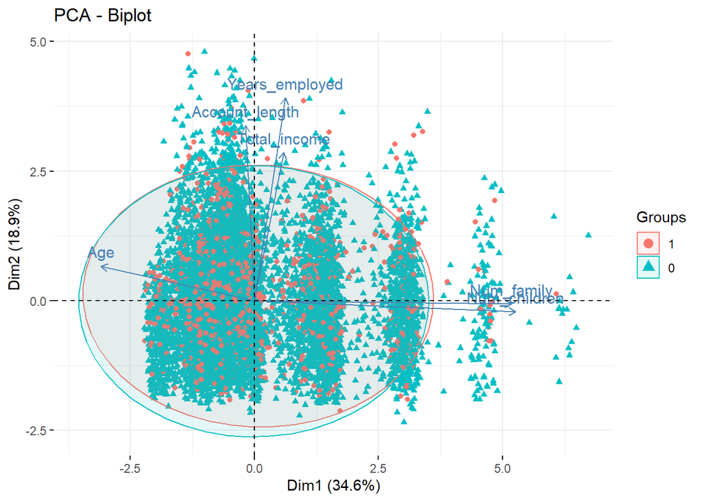

```r
result_pca <- PCA(dataset[, sapply(dataset, is.numeric)], graph = FALSE)

fviz_pca_biplot(result_pca, label="var", habillage=dataset$Target,
               addEllipses=TRUE, ellipse.level=0.95)
```

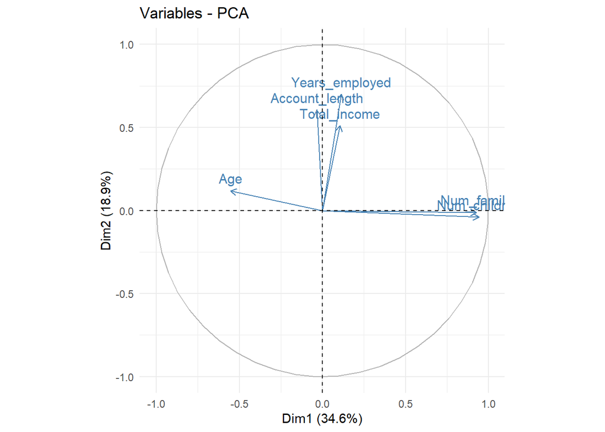

```r
table_data <- table(dataset$Education_type, dataset$Housing_type)

fviz_pca_var(result_pca, col.var="steelblue")+
 theme_minimal()
```

[figure not shown]

```r
fviz_pca_var(result_pca, col.var="contrib")+
 scale_color_gradient2(low="white", mid="blue",
           high="red", midpoint=96) +
 theme_minimal()
```

### Conclusiones

Aunque los datos no muestran una separación clara de los grupos en las dos primeras componentes principales, la orientación y contribución de las variables sugieren que es posible que ciertos factores, como la estabilidad financiera (ingresos y años empleados) y la estructura familiar (número de miembros de la familia), jueguen roles importantes en diferenciar subgrupos dentro del conjunto de datos.

### Pregunta 3

- ¿Es posible predecir si una persona es elegible para una tarjeta de crédito?
- Hipótesis: Utilizando un modelo predictivo es posible predecir si un solicitante será aprobado para una tarjeta de crédito.

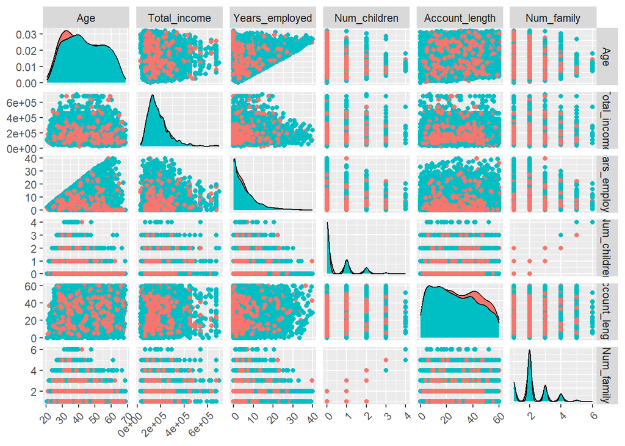

```r
ggpairs(dataset, columns = c("Age", "Total_income", "Years_employed","Num_children","Account_length","Num_family"),
        aes(color = Target),upper = list(continuous = "points"))+
      theme(axis.text.x = element_text(angle = 45, hjust = 1))
```

### Conclusiones

El análisis muestra que no hay una única variable que pueda predecir de manera confiable el resultado. Esto indica la complejidad del proceso de toma de decisiones que probablemente involucra múltiples factores y posiblemente interacciones complejas entre estas variables.